[Imtiaj.](https://imtiajiqbalmahfuj.github.io/index.html#top)

# Bivariate Climate Mapping: Temperature × Precipitation

### Advanced Spatial Visualization of Climate Extremes in Bangladesh and India

> *Synthesizing two dimensions of climate data into a single, high-fidelity visual narrative using Python.* 🌡️🌧️

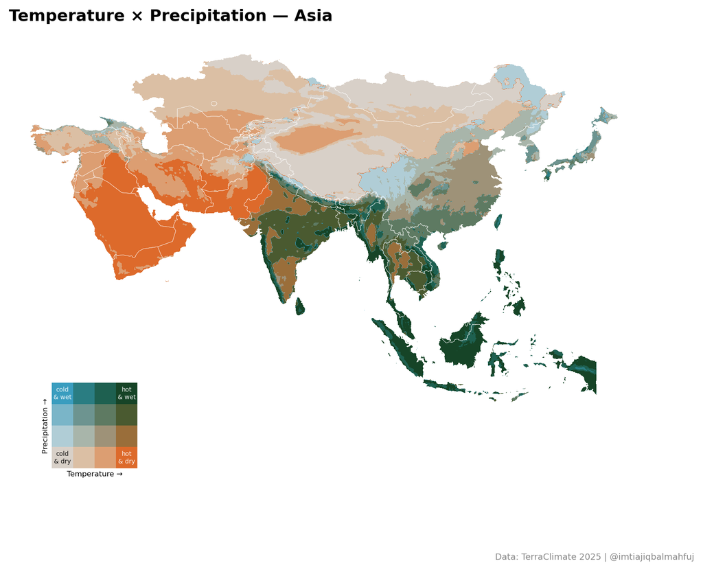

> **Author:** Imtiaj Iqbal Mahfuj

## 📝 Overview

This project explores **spatial patterns** of climate variability by integrating **remote sensing datasets** from TerraClimate and applying **geospatial Python tools** to visualize the intersection of temperature and precipitation. Unlike traditional choropleth maps that display a single variable, this bivariate approach encodes two variables simultaneously into a 2D color matrix, uncovering the complex relationship between heat and moisture.

**Problem Statement:** Standard climate maps often fail to show the correlation between different environmental stressors. This project addresses the need for a unified visualization that can identify "Hot-Dry" versus "Hot-Wet" zones, which is critical for understanding regional climate risks in the Indian Subcontinent.

**Objectives:**

- Recreate a high-fidelity, viral climate visualization using a purely Python-based workflow.
- Implement Gaussian smoothing to eliminate the "blocky" artifacts of raw satellite data.
- Analyze the climatic distribution of Bangladesh and India using 2025 TerraClimate NetCDF data.

**Beneficiaries:** This work serves urban planners, climate researchers, and policy-makers who require intuitive, data-driven insights into regional environmental conditions.

## 🛠️ Tools & Technologies

## ⚙️ Methodology

| Step | Description |
| --- | --- |
| 1. Data Collection | Acquisition of NetCDF files (tmax and ppt) from the University of Idaho's Climatology Lab (TerraClimate 2025). |
| 2. Preprocessing | Utilizing `rioxarray` and `geopandas` to clip the global rasters to the specific administrative boundaries of India and Bangladesh. |
| 3. Analysis | Applying asymmetric quantile classification to segment data into a 4x4 grid, focusing on extremes (e.g., top 10% precipitation). |
| 4. Visualization | Implementing a Gaussian filter via `scipy.ndimage` for aesthetic smoothing and rendering the final map with a custom legend inset. |

## 📊 Results & Insights

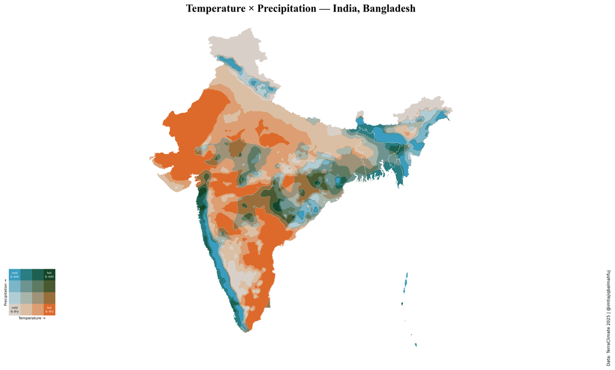

Bangladesh

Bangladesh

South America

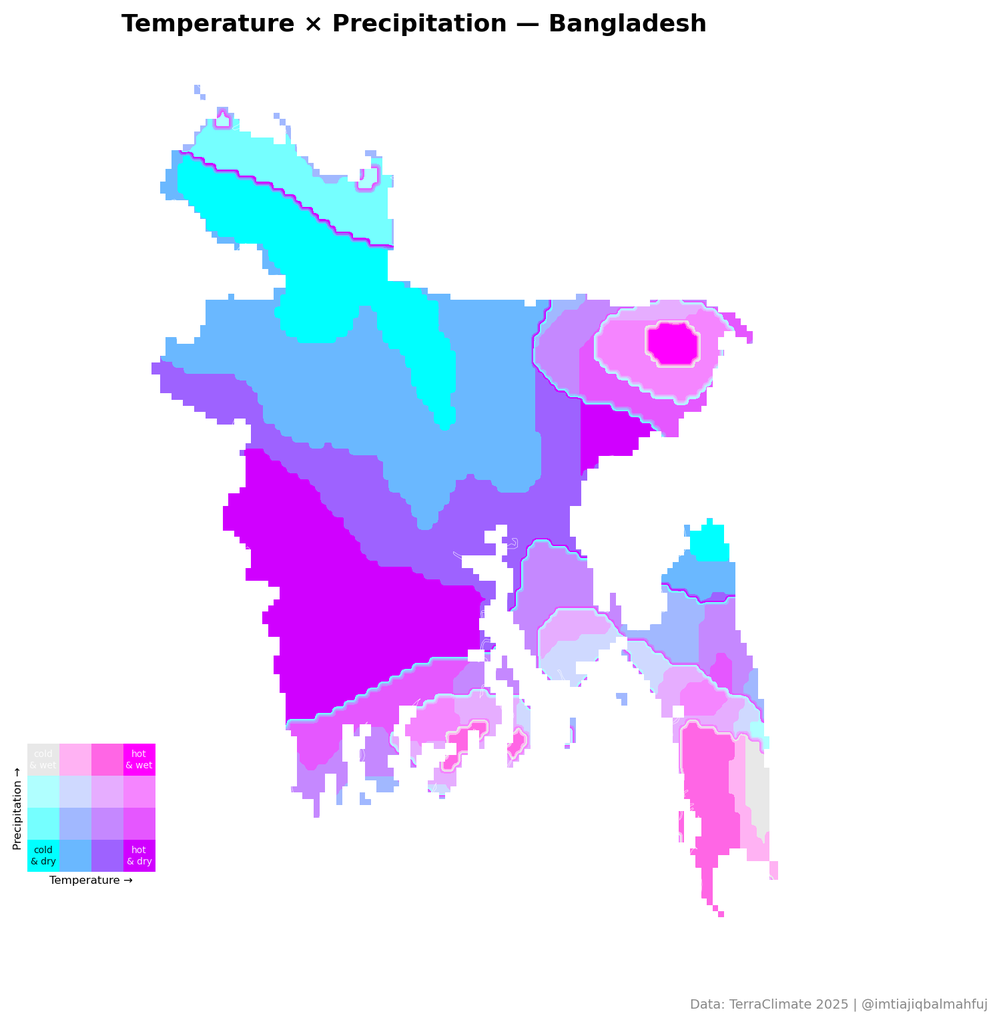

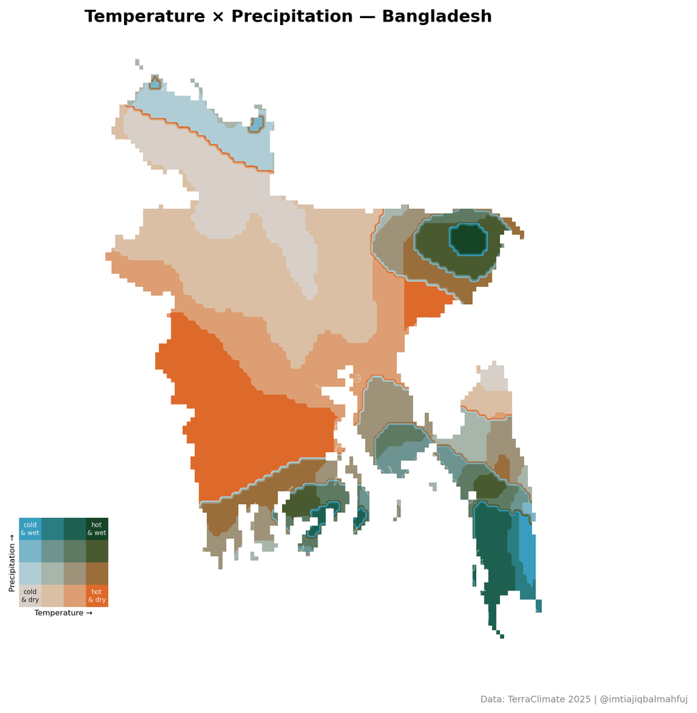

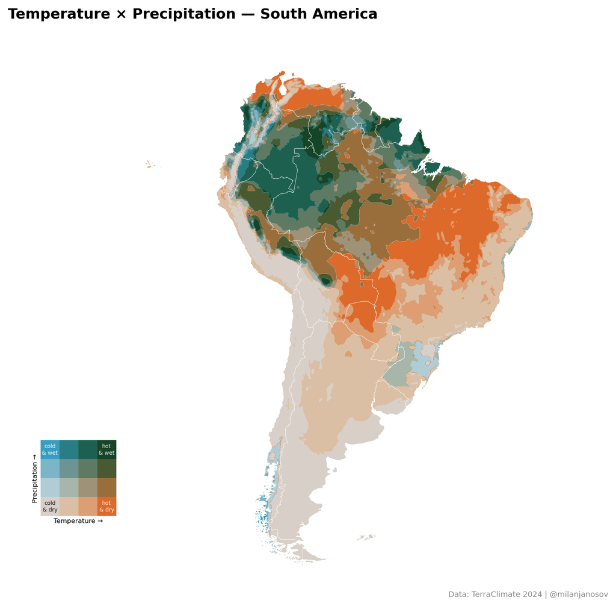

# Codes⬇️

## CONFIG

```python
# Data files — download from https://www.climatologylab.org/terraclimate.html
# Pick a year, select variables tmax and ppt, download as NetCDF
TMAX_FILE = "TerraClimate_tmax_2025.nc"
PPT_FILE  = "TerraClimate_ppt_2025.nc"
BORDERS   = "ne_10m_admin_0_countries.zip"  # Natural Earth 1:10m countries
```

```python
# ── REGION ───────────────────────────────────────────────────────────────────
# Three ways to define a region — uncomment the one you want:

REGION = ["India", "Bangladesh"]
# REGION = "South America"           # a continent name
# REGION = ["Germany", "France"]   # a list of country names
# REGION = "World"                  # the whole world
```

```python
# ── COLOR & SMOOTHING ─────────────────────────────────────────────────────────
N     = 4     # palette grid size — 4×4 = 16 colors, matches the reference
SIGMA = 2.0   # Gaussian smoothing strength — higher = smoother blobs

# ── QUANTILE BREAK PERCENTILES ────────────────────────────────────────────────
# These control the orange/blue balance.
# Equal bins would be [0, 25, 50, 75, 100] — each bin gets 25% of pixels.
# We skew them so more pixels fall into warm/dry bins → more orange, less teal.
#
# Temp: top 30% of pixels are ‘hot’ (above the 70th percentile)
# Ppt:  top 10% of pixels are ‘very wet’ (above the 90th percentile)
TEMP_BREAKS = [0, 20, 45, 70, 100]
PPT_BREAKS  = [0, 60, 78, 90, 100]
```

```python
# ── PALETTE ───────────────────────────────────────────────────────────────────
# 4×4 color matrix — hex codes sampled directly from the reference image.
# Layout:
#   row 0 = high precipitation (top of legend)    → teal / blue-green
#   row 3 = low  precipitation (bottom of legend) → grey / peach / orange
#   col 0 = low  temperature   (left of legend)   → cool tones
#   col 3 = high temperature   (right of legend)  → warm tones

PALETTE = [ #blue_orange_green
    ["#3a9dbf", "#2a7d82", "#1e6050", "#164427"],  # high precip
    ["#7ab5c8", "#6d9490", "#5e7a62", "#4a5a30"],
    ["#b0cdd6", "#a8b5aa", "#9e9278", "#9a6e3a"],
    ["#d8d0c8", "#dbbfa4", "#dc9e72", "#dd6a2b"],  # low precip
]

# # ── CYAN-MAGENTA BIVARIATE PALETTE ────────────────────────────────────────────
# # row 0 = high precipitation (Cyan → Violet)
# # row 3 = low  precipitation (White/Grey → Magenta)
# #
# # Layout Logic:
# # [3,0] = Neutral Base   [3,3] = Pure Magenta (Hot/Dry)
# # [0,0] = Pure Cyan (Wet) [0,3] = Electric Violet (Hot/Wet)

# PALETTE = [
#     ["#00ffff", "#6ab8ff", "#9e62ff", "#d000ff"],  # High Precip (Cyan to Violet)
#     ["#75ffff", "#a1b8ff", "#c588ff", "#e557ff"],
#     ["#b0ffff", "#cfd9ff", "#e6adff", "#f585ff"],
#     ["#e8e8e8", "#ffb2f3", "#ff66e5", "#ff00ff"],  # Low Precip (Grey to Magenta)
# ]

# # ── MAGENTA-CYAN BIVARIATE PALETTE ────────────────────────────────────────────
# # row 0 = high precipitation (Cyan → Violet)
# # row 3 = low  precipitation (White/Grey → Magenta)
# #
# # Layout Logic:
# # [3,0] = Neutral Base   [3,3] = Pure Magenta (Hot/Dry)
# # [0,0] = Pure Cyan (Wet) [0,3] = Electric Violet (Hot/Wet)

# PALETTE = [
#     ["#e8e8e8", "#ffb2f3", "#ff66e5", "#ff00ff"],  # High Precip (Cyan to Violet)
#     ["#b0ffff", "#cfd9ff", "#e6adff", "#f585ff"],
#     ["#75ffff", "#a1b8ff", "#c588ff", "#e557ff"],
#     ["#00ffff", "#6ab8ff", "#9e62ff", "#d000ff"],  # Low Precip (Grey to Magenta)
# ]


FIGSIZE = (16, 9)
```

## IMPORTS

```python
# Four libraries do the heavy lifting:
#   xarray     — reads NetCDF files (the standard format for gridded climate data)
#   rioxarray  — adds spatial clipping and CRS support to xarray DataArrays
#   geopandas  — loads country/continent boundaries as vector polygons
#   scipy      — provides the Gaussian filter for smoothing
#
# Run this once to install if needed:
# !pip install xarray rioxarray geopandas matplotlib numpy netCDF4 scipy

import numpy as np
import xarray as xr
import rioxarray
import geopandas as gpd
import matplotlib.pyplot as plt
import matplotlib.colors as mcolors
from scipy.ndimage import gaussian_filter
```

## LOAD & CLIP

```python
# TerraClimate files are NetCDF — a multi-dimensional array format used throughout
# climate science. Each file contains monthly data for a full year.
#
# We compute:
#   - tmax: annual MEAN of monthly maximum temperatures (already in °C — xarray
#            applies the scale factor automatically from the file metadata)
#   - ppt:  annual SUM of monthly precipitation (mm/year)
#            We use sum rather than mean so the quantile breaks spread more
#            evenly across the precipitation range.
#
# Then we write the CRS (WGS84) so rioxarray can do spatial clipping,
# load the country boundaries, select the region, and clip both rasters to it.

tmax_da = xr.open_dataset(TMAX_FILE, engine="netcdf4")["tmax"].mean("time")
ppt_da  = xr.open_dataset(PPT_FILE,  engine="netcdf4")["ppt"].sum("time")

tmax_da = tmax_da.rio.write_crs("EPSG:4326")
ppt_da  = ppt_da.rio.write_crs("EPSG:4326")

# Select the region from Natural Earth boundaries
world = gpd.read_file(BORDERS)
if isinstance(REGION, list):
    region_gdf = world[world["ADMIN"].isin(REGION)]
    print(f"Countries: {REGION}")
elif REGION == "World":
    region_gdf = world.copy()
    print("Region: World")
else:
    region_gdf = world[world["CONTINENT"] == REGION]
    print(f"Continent: {REGION} — {len(region_gdf)} countries")

# Clip both rasters to the region boundary
tmax_clip = tmax_da.rio.clip(region_gdf.geometry, region_gdf.crs, drop=True)
ppt_clip  = ppt_da.rio.clip(region_gdf.geometry,  region_gdf.crs, drop=True)

print(f"Grid size: {tmax_clip.shape}")
print(f"Temp:   {float(tmax_clip.min()):.1f}°C → {float(tmax_clip.max()):.1f}°C")
print(f"Precip: {float(ppt_clip.min()):.0f} → {float(ppt_clip.max()):.0f} mm/yr")
```

```
Countries: ['India', 'Bangladesh']
Grid size: (690, 701)
Temp:   -14.4°C → 37.1°C
Precip: 0 → 8622 mm/yr
```

## BIVARIATE PALETTE

```
Corner check:
  cold & dry  (idx  0): (0.8470588235294118, 0.8156862745098039, 0.7843137254901961)  → should be light grey
  hot  & dry  (idx  3): (0.8666666666666667, 0.41568627450980394, 0.16862745098039217)  → should be orange
  cold & wet  (idx 12): (0.22745098039215686, 0.615686274509804, 0.7490196078431373) → should be teal/blue
  hot  & wet  (idx 15): (0.08627450980392157, 0.26666666666666666, 0.15294117647058825) → should be dark green
```

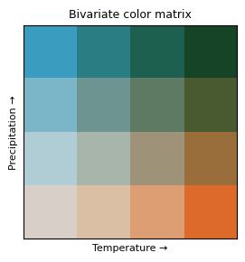

```python
# The core idea: instead of one color ramp, we build a 2D color matrix.
# Each cell in the N×N grid represents a combination of temperature and
# precipitation quantile bins.
#
# The 16 hex codes were sampled directly from the reference image using
# pixel color picking — no color math needed, we just use the exact values.
#
# The flat_colors list maps to bi_grid indices via:
#   index = ppt_quantile * N + temp_quantile
#
# So ppt_q=0 (driest) must map to the bottom row of the palette (grey/orange),
# and ppt_q=3 (wettest) must map to the top row (teal/dark green).
# That’s why we flip the row index: palette_row = N - 1 - ppt_q

def hex_to_rgb(h):
    """Convert a hex color string to a normalised (r, g, b) tuple."""
    h = h.lstrip("#")
    return tuple(int(h[i:i+2], 16) / 255.0 for i in (0, 2, 4))

# Build the flat colormap — order must match bi_grid = ppt_q * N + temp_q
flat_colors = [hex_to_rgb(PALETTE[N - 1 - pq][tq])
               for pq in range(N)   # pq=0 → dry → PALETTE row 3
               for tq in range(N)]  # tq=0 → cold → PALETTE col 0

cmap = mcolors.ListedColormap(flat_colors)

# Build the legend grid separately — row 0 at bottom = dry, row N-1 at top = wet
legend_grid = np.array([[hex_to_rgb(PALETTE[N - 1 - row][col])
                          for col in range(N)]
                         for row in range(N)])

# Quick sanity check — verify the four corners are correct
print("Corner check:")
print(f"  cold & dry  (idx  0): {flat_colors[0]}  → should be light grey")
print(f"  hot  & dry  (idx  3): {flat_colors[3]}  → should be orange")
print(f"  cold & wet  (idx 12): {flat_colors[12]} → should be teal/blue")
print(f"  hot  & wet  (idx 15): {flat_colors[15]} → should be dark green")

# Preview the color matrix
fig, ax = plt.subplots(figsize=(3, 3))
ax.imshow(legend_grid, origin="lower", aspect="equal")
ax.set_xlabel("Temperature →", fontsize=8)
ax.set_ylabel("Precipitation →", fontsize=8)
ax.set_xticks([]); ax.set_yticks([])
ax.set_title("Bivariate color matrix", fontsize=9)
plt.tight_layout()
plt.show()
```

## CLASSIFY + SMOOTH

```python
# Step 1 — Quantile classification
#   For each pixel we ask: which temperature bin does it fall in? (0 to N-1)
#   Then: which precipitation bin? (0 to N-1)
#   Then combine: index = ppt_bin * N + temp_bin
#   This single integer maps to one color in our palette.
#
#   We use *asymmetric* percentile breaks instead of equal-frequency bins.
#   Equal bins would put exactly 25% of pixels in each category — but that
#   makes a tropical continent like South America look too uniformly wet/warm.
#   Skewed breaks push more pixels into the dry/warm categories, so the map
#   shows more orange and reserves the deep teal for truly exceptional rainfall.
#
# Step 2 — Gaussian smoothing
#   TerraClimate has ~4km resolution which looks blocky at continent scale.
#   We smooth the raw temperature and precipitation arrays with a Gaussian
#   filter, then reclassify the smoothed values using the same breaks.

#   This blends boundaries between zones without changing the data interpretation.
temp_vals  = tmax_clip.values.flatten()
ppt_vals   = ppt_clip.values.flatten()
valid      = ~np.isnan(temp_vals) & ~np.isnan(ppt_vals)

# Compute break thresholds from the actual data distribution
t_breaks = np.nanpercentile(temp_vals[valid], TEMP_BREAKS)
p_breaks = np.nanpercentile(ppt_vals[valid],  PPT_BREAKS)

def qbin(arr, breaks):
    """Assign values to quantile bins [0, N-1]."""
    return np.clip(np.digitize(arr, breaks[1:-1]), 0, len(breaks) - 2)

# Smooth the raw rasters first, then reclassify
# (smoothing then classifying gives cleaner zone boundaries
#  than classifying then smoothing)
nan_mask = np.isnan(tmax_clip.values) | np.isnan(ppt_clip.values)

def smooth(arr):
    """Fill NaN with mean, apply Gaussian blur, return smoothed array."""
    filled = np.where(nan_mask, np.nanmean(arr), arr)
    return gaussian_filter(filled, sigma=SIGMA)

ts = smooth(tmax_clip.values).flatten()
ps = smooth(ppt_clip.values).flatten()
vm = ~nan_mask.flatten()

tq = np.full(ts.shape, -1, dtype=int)
pq = np.full(ps.shape, -1, dtype=int)
tq[vm] = qbin(ts[vm], t_breaks)
pq[vm] = qbin(ps[vm], p_breaks)

# Combined bivariate class — single integer per pixel
bi_grid = np.where(~nan_mask,
                   pq.reshape(nan_mask.shape) * N + tq.reshape(nan_mask.shape),
                   np.nan)

print(f"Grid shape: {bi_grid.shape}")
print(f"Value range: {np.nanmin(bi_grid):.0f} → {np.nanmax(bi_grid):.0f}  (expected 0–{N**2-1})")
print(f"Temp breaks:  {[f'{v:.1f}' for v in t_breaks]}")
print(f"Precip breaks: {[f'{v:.0f}' for v in p_breaks]}")
```

```
Grid shape: (690, 701)
Value range: 0 → 15  (expected 0–15)
Temp breaks:  ['-14.4', '30.1', '31.4', '32.4', '37.1']
Precip breaks: ['31', '1517', '1845', '2215', '8622']
```

## PLOT

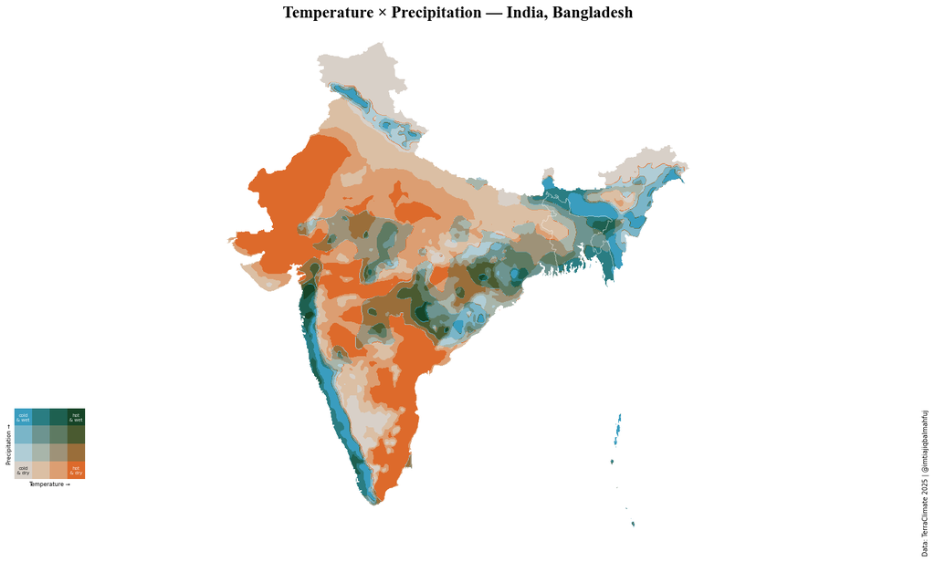

```
Saved: bivariate_india_bangladesh.png
```

```python
# The map has four elements:
#   1. The bivariate raster — rendered with imshow using our custom colormap
#   2. Country/region borders — plotted on top as thin white lines
#   3. A legend inset — the 4×4 color matrix in the bottom-left corner
#   4. Corner labels on the legend — "cold & dry", "hot & wet" etc.
#      These make the map readable without needing to explain the color system.
#
# The legend corner labels use white text on dark cells and black on the
# light grey corner (cold & dry) so they’re always readable.

def draw_legend(ax, grid_rgb, n, text_color="k", fontsize=6):
    """Draw the 2D color legend with axis labels and corner annotations."""
    ax.imshow(grid_rgb, origin="lower", aspect="equal",
              extent=[0, n, 0, n], interpolation="nearest")
    ax.set_xlabel("Temperature →", fontsize=fontsize, color=text_color, labelpad=2)
    ax.set_ylabel("Precipitation →", fontsize=fontsize, color=text_color, labelpad=2)
    ax.set_xticks([]); ax.set_yticks([])

    # Remove border
    for sp in ax.spines.values():
        sp.set_visible(False)

    # Corner labels — black on light corner, white on dark corners
    # (Matches our Cyan-Magenta-Violet logic)
    kw = dict(fontsize=fontsize - 1, ha="center", va="center",
              alpha=0.9, linespacing=1.3, transform=ax.transData)
    ax.text(0.5,     0.5,     "cold\n& dry", color="k", **kw) # Light Grey
    ax.text(n - 0.5, 0.5,     "hot\n& dry",  color="w", **kw) # Magenta
    ax.text(0.5,     n - 0.5, "cold\n& wet", color="w", **kw) # Cyan
    ax.text(n - 0.5, n - 0.5, "hot\n& wet",  color="w", **kw) # Violet

# Compute extent and bounds for the map axes
lons   = tmax_clip.coords["lon"].values
lats   = tmax_clip.coords["lat"].values
extent = [lons.min(), lons.max(), lats.min(), lats.max()]
bounds = region_gdf.total_bounds   # [minx, miny, maxx, maxy]
pad    = max(bounds[2] - bounds[0], bounds[3] - bounds[1]) * 0.03

# Build the figure
fig = plt.figure(figsize=FIGSIZE, facecolor="white")
ax  = fig.add_axes([0.04, 0.04, 0.98, 0.88], facecolor="white")

# Bivariate raster
ax.imshow(bi_grid, cmap=cmap, vmin=0, vmax=N**2 - 1,
          extent=extent, origin="upper", aspect="auto",
          interpolation="bilinear", zorder=1)

# Country borders
region_gdf.boundary.plot(ax=ax, linewidth=0.2, color="white", zorder=2)

# Zoom to the region with a small padding buffer
ax.set_xlim(bounds[0] - pad, bounds[2] + pad)
ax.set_ylim(bounds[1] - pad, bounds[3] + pad)
ax.axis("off")

# Title
title = REGION if isinstance(REGION, str) else ", ".join(REGION)
ax.set_title(f"Temperature × Precipitation — {title}",
             color="k", fontname="Times New Roman", fontsize=18, fontweight="bold", pad=10, loc="center")

# Legend inset — bottom-left corner of the figure
# Adjusted slightly to ensure it fits the square matrix
ax_leg = fig.add_axes([0.08, 0.15, 0.12, 0.12], facecolor="white")
draw_legend(ax_leg, legend_grid, N)


# Data credit
fig.text(0.98, 0.02, "Data: TerraClimate 2025 | @imtiajiqbalmahfuj",
         ha="right", va="bottom", fontsize=7, color="k", rotation = 'vertical')

# Save
fname = title.lower().replace(" ", "_").replace(",", "")
plt.savefig(f"bivariate_{fname}3.png", dpi=200,
            bbox_inches="tight", facecolor="white")
plt.show()
print(f"Saved: bivariate_{fname}.png")
```

## ❓ Why this project?

- **Bridging the Gap:** This project bridges the gap between complex climate modeling and accessible visual communication.
- **Technological Mastery:** It demonstrates a transition from being a "noob" in R/JS to mastering high-level geospatial Python workflows.
- **Impact:** Such visualizations are vital for disaster management and agricultural planning in South Asia, where monsoon patterns and heatwaves intersect.

## 📎 Links

- 🔗 See post on LinkedIn
- 🔗 [See more on LinkedIn](https://www.linkedin.com/in/imtiajiqbalmahfuj)
- 📄 [Portfolio Project Gallery](https://imtiajiqbalmahfuj.github.io/)

## 🔖 Tags

`GIS` `Remote Sensing` `Geospatial Python` `Python` `Climate-Change` `Spatial Data-Science` `Bivariate-Mapping` `TerraClimate`

## 📌 Credits & Shoutouts

- 👨‍💻 **Author:** [Imtiaj Iqbal Mahfuj](https://imtiajiqbalmahfuj.github.io/)
- 🙌 **Inspiration:** Special thanks to **Milan Janosov** for the Python tutorial and **Milos Makes Maps** for the original creative spark.
- 🗂️ **Data Sources:** TerraClimate (University of Idaho), Natural Earth (Borders).

## 💬 Connect with Me

📧 Email: imtiajiqbal.ruet@gmail.com 🌐 Portfolio: https://imtiajiqbalmahfuj.github.io/